# Regularization

Author

Dr. Niloufar Abourashchi and Dr. Thomas Honnor

# Introduction

## Recap

We have considered linear regression models for an outcome, $Y$, using covariates, $X_1, X_2, ..., X_p$, of the form:
$$\begin{align*}
Y=\beta_0 + \beta_1X_1 + \beta_2X_2 + ... + \beta_pX_p
\end{align*}$$

Such models are fitted to data, $y$ and $x_1, x_2, ..., x_p$, by minimising the residual sum of squares, $RSS$:
$$\begin{align*}
RSS &= \sum_{i=1}^n (y_i-\hat{y}_i)^2 \\
&= \sum_{i=1}^n \left(y_i - \lbrace \beta_0+\beta_1x_{1,i}+\beta_2x_{2,i}+...+\beta_px_{p,i}\rbrace \right)^2
\end{align*}$$

The collection of coefficients which minimise the $RSS$ are then reported as $\hat{\beta}_0, \hat{\beta}_1, \hat{\beta}_2, ..., \hat{\beta}_p$.

For students who have seen more statistical theory, this process of minimising the residual sum of squares is equivalent to a process of maximising the likelihood. The obtained coefficients above may therefore be referred to as maximum likelihood estimates of the coefficients.

Note that we have previously seen the potential for transforming covariates. The discussion which follows works under the scenario outlined at the top of this section – that we have a fixed collection of covariates, $X_1, X_2, ..., X_p$. These could well be transformed versions of other covariates which have then been discarded, e.g. $X_1=f(Z)$, or transformations of the other available covariates, e.g. $X_2=f(X_1)$. In this sense, our decision to focus here on a fixed set of covariates is not unnecessarily restrictive.

## The problem

We have seen the potential pitfalls of overfitting, where the fitted model performs well for the data used to train the model, but through learning the specific nuances of the training data in great detail performs poorly for new test data.

Determining the best model to be the one which minimises the residual sum of squares will always result in the full model – the model containing all of the covariates. Identifying a best model by minimising the residual sum of squares is identical to selecting the model with the highest $R^2$.

We have seen ways to circumvent this issue – selecting models using alternative metrics such as $Adjusted\ R^2$, $AIC$, and cross validated error.

In a scenario where there are $p$ different covariates, there are a total of $2^p$ different models. That is, for each covariate, $X_i$, we can make one of two choices – to include $X_i$ in our model or not to include $X_i$ in our model. The two choices for each $X_i$ combine multiplicatively, to give us the $2^p$ different possible models. In the case where $p$ is moderately large this can quickly be prohibitive ($2^{10}=1 024, 2^{20}=1 048 576, ...$). This can make all subsets regression computationally infeasible (particularly when the metric used for comparing models is the cross validated error, as $k$-fold cross validation requires the model under consideration to be fitted $k$ times).

Consider instead the potential for stepwise regression. In a scenario where there are $p$ different covariates there are a total of $p$ different models with one covariate. Once the best such model has been fitted, there are then a potential $p-1$ models which take that first chosen covariate and add a second one. There are then $p-2$ models which take those first two covariates and add on a third one, and so on and so on until we are left with a single choice of covariate to add to result in the full model. That is, stepwise regression can lead to us fitting $p+(p-1)+(p-2)+...+1=\frac{1}{2}p(p+1)$ different models. This can be a large number, but is certainly more manageable than all subsets regression ($\frac{1}{2}10(10+1)=55, \frac{1}{2}20(20+1)=210, ...$).

While stepwise regression therefore results in the fitting of fewer models, bringing with it computational benefits, it is a greedy process which provides no guarantee of resulting in the model with the overall optimal criteria (whether that be $Adjusted\ R^2$, $AIC$ or cross validated error). The greater the number of covariates, the smaller the fraction of all possible models which stepwise regression ever gets to consider, and thus the greater the chance that it fails to find the best model.

# Regularization

$Adjusted\ R^2$ is of a form akin to:
$$\begin{align*}
Adjusted\ R^2 = \frac{model\ fit}{model\ complexity}
\end{align*}$$
In this sense we prioritise improvements in model fit, but only when the improvement in model fit outweighs the increase in model complexity.

$AIC$ is of a form akin to:
$$\begin{align*}
AIC = model\ complexity - model\ fit
\end{align*}$$
Remembering that we prefer smaller values of $AIC$, this again prioritises improvement in model fit only when the improvement in model fit outweighs the improvement in complexity.

Perhaps, instead of fitting models by minimising the residual sum of squares and then using measures like $Adjusted\ R^2$ and $AIC$ to penalise model complexity, we might instead fit the model in an alternative way which itself penalises model complexity. For example, consider minimising:
$$\begin{align*}
RSS^* &= RSS + model\ complexity \\
&= \sum_{i=1}^n (y_i-\hat{y}_i)^2 + model\ complexity \\
&= \sum_{i=1}^n \left(y_i - \lbrace \beta_0+\beta_1x_{1,i}+\beta_2x_{2,i}+...+\beta_px_{p,i}\rbrace \right)^2 + model\ complexity
\end{align*}$$

$RSS^*$ might then be referred to as a regularized version of $RSS$. By minimising $RSS^*$ we might in a single step identify the model which most appropriately trades off model fit against model complexity, and thus lies in the sweet spot between underfitting and overfitting.

## The lasso

One approach to setting the penalty term leads to what is referred to as the lasso. Under this methodology, the selected model is the one which minimises:
$$\begin{align*}
RSS^* &= \sum_{i=1}^n \left(y_i - \lbrace \beta_0+\beta_1x_{1,i}+\beta_2x_{2,i}+...+\beta_px_{p,i}\rbrace \right)^2 + \lambda\sum_{j=1}^p|\beta_j|
\end{align*}$$

The penalty term quantifies model complexity by the sum of the absolute values of the coefficient estimates. Coefficients which are zero, reflecting covariates which are excluded from the model, contribute nothing to this penalty term and are therefore preferred.

The tuning parameter, $\lambda\geq 0$, allows increased/decreased weight to be applied to the model complexity term. The impact of $\lambda$ on the fitted model can be understood by considering its extremes.

When $\lambda=0$ we return to simply minimising the residual sum of squares, resulting in the full model being recommended. In this case there is large variability in the model coefficients (different observed data could produce dramatically different coefficient estimates) and little bias in the model coefficients (standard linear regression results in unbiased coefficient estimates), with a corresponding large test data error because the model is overfitting.

When $\lambda$ is very large, we are mainly focused on reducing the sizes of the coefficients and the actual error as measured by the residual sum of squares is of very little importance. In this case there is small variability in the model coefficients (as they are all driven towards zero) and large bias in the model coefficients (as they are driven far away from their least squares values), with a corresponding larger test data error because the model is underfitting.

For moderate values of $\lambda$ we obtain moderate levels of variability in the model coefficients and moderate amount of bias in the model coefficients, with a subsequently lower test data error as the sweet spot is reached in the tradeoff between bias and variance.

How do we determine the optimal value of $\lambda$? Borrowing from similar situations we’ve faced in the past, cross validation.

To explore the lasso in action, we apply it to some data quantifying wine quality against a variety of chemical properties.

```r
library(glmnet)
library(tidyverse)
```

```r
wine <- read_csv("wine.csv")
names(wine)[1] <- "f_acidity"
names(wine)[2] <- "v_acidity"
names(wine)[3] <- "citric_acid"
names(wine)[6] <- "free_so2"
names(wine)[7] <- "total_so2"
names(wine)[4] <- "res_sugar"

glimpse(wine)
```

```
Rows: 1,599
Columns: 12
$ f_acidity   <dbl> 7.4, 7.8, 7.8, 11.2, 7.4, 7.4, 7.9, 7.3, 7.8, 7.5, 6.7, 7.…
$ v_acidity   <dbl> 0.700, 0.880, 0.760, 0.280, 0.700, 0.660, 0.600, 0.650, 0.…
$ citric_acid <dbl> 0.00, 0.00, 0.04, 0.56, 0.00, 0.00, 0.06, 0.00, 0.02, 0.36…
$ res_sugar   <dbl> 1.9, 2.6, 2.3, 1.9, 1.9, 1.8, 1.6, 1.2, 2.0, 6.1, 1.8, 6.1…
$ chlorides   <dbl> 0.076, 0.098, 0.092, 0.075, 0.076, 0.075, 0.069, 0.065, 0.…
$ free_so2    <dbl> 11, 25, 15, 17, 11, 13, 15, 15, 9, 17, 15, 17, 16, 9, 52, …
$ total_so2   <dbl> 34, 67, 54, 60, 34, 40, 59, 21, 18, 102, 65, 102, 59, 29, …
$ density     <dbl> 0.9978, 0.9968, 0.9970, 0.9980, 0.9978, 0.9978, 0.9964, 0.…
$ pH          <dbl> 3.51, 3.20, 3.26, 3.16, 3.51, 3.51, 3.30, 3.39, 3.36, 3.35…
$ sulphates   <dbl> 0.56, 0.68, 0.65, 0.58, 0.56, 0.56, 0.46, 0.47, 0.57, 0.80…
$ alcohol     <dbl> 9.4, 9.8, 9.8, 9.8, 9.4, 9.4, 9.4, 10.0, 9.5, 10.5, 9.2, 1…
$ quality     <dbl> 5, 5, 5, 6, 5, 5, 5, 7, 7, 5, 5, 5, 5, 5, 5, 5, 7, 5, 4, 6…
```

```r
str(wine)
```

```
spc_tbl_ [1,599 × 12] (S3: spec_tbl_df/tbl_df/tbl/data.frame)
 $ f_acidity  : num [1:1599] 7.4 7.8 7.8 11.2 7.4 7.4 7.9 7.3 7.8 7.5 ...
 $ v_acidity  : num [1:1599] 0.7 0.88 0.76 0.28 0.7 0.66 0.6 0.65 0.58 0.5 ...
 $ citric_acid: num [1:1599] 0 0 0.04 0.56 0 0 0.06 0 0.02 0.36 ...
 $ res_sugar  : num [1:1599] 1.9 2.6 2.3 1.9 1.9 1.8 1.6 1.2 2 6.1 ...
 $ chlorides  : num [1:1599] 0.076 0.098 0.092 0.075 0.076 0.075 0.069 0.065 0.073 0.071 ...
 $ free_so2   : num [1:1599] 11 25 15 17 11 13 15 15 9 17 ...
 $ total_so2  : num [1:1599] 34 67 54 60 34 40 59 21 18 102 ...
 $ density    : num [1:1599] 0.998 0.997 0.997 0.998 0.998 ...
 $ pH         : num [1:1599] 3.51 3.2 3.26 3.16 3.51 3.51 3.3 3.39 3.36 3.35 ...
 $ sulphates  : num [1:1599] 0.56 0.68 0.65 0.58 0.56 0.56 0.46 0.47 0.57 0.8 ...
 $ alcohol    : num [1:1599] 9.4 9.8 9.8 9.8 9.4 9.4 9.4 10 9.5 10.5 ...
 $ quality    : num [1:1599] 5 5 5 6 5 5 5 7 7 5 ...
 - attr(*, "spec")=
  .. cols(
  ..   `fixed acidity` = col_double(),
  ..   `volatile acidity` = col_double(),
  ..   `citric acid` = col_double(),
  ..   `residual sugar` = col_double(),
  ..   chlorides = col_double(),
  ..   `free sulfur dioxide` = col_double(),
  ..   `total sulfur dioxide` = col_double(),
  ..   density = col_double(),
  ..   pH = col_double(),
  ..   sulphates = col_double(),
  ..   alcohol = col_double(),
  ..   quality = col_double()
  .. )
 - attr(*, "problems")=<externalptr>
```

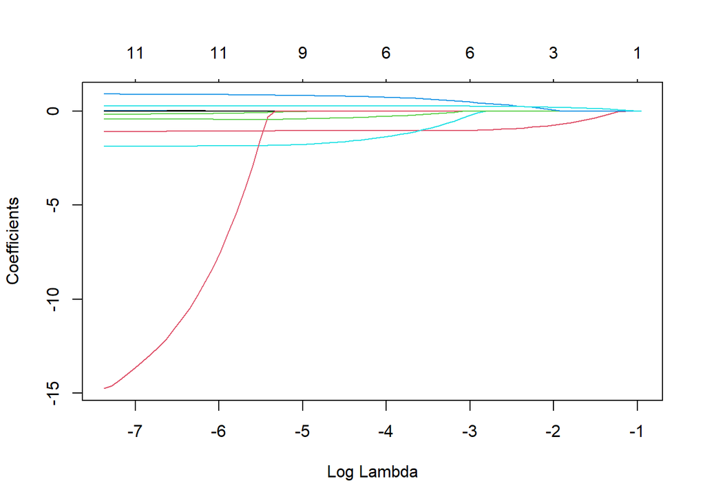

```r
wine_x <- select(wine, -quality)
wine_y <- wine$quality

fit_lasso <- glmnet(x=data.matrix(wine_x),
                    y=wine_y,
                    alpha = 1)
plot(fit_lasso, xvar="lambda")
```

See how, as (the logarithm of) $\lambda$ increases, coefficient values are “shrunk” towards zero. The numbers along the top of the plot indicate how many non-zero coefficients there are in the model, reducing from the full set of $11$ available coefficients at the smallest values of $\lambda$ to only a single coefficient at the largest values of $\lambda$.

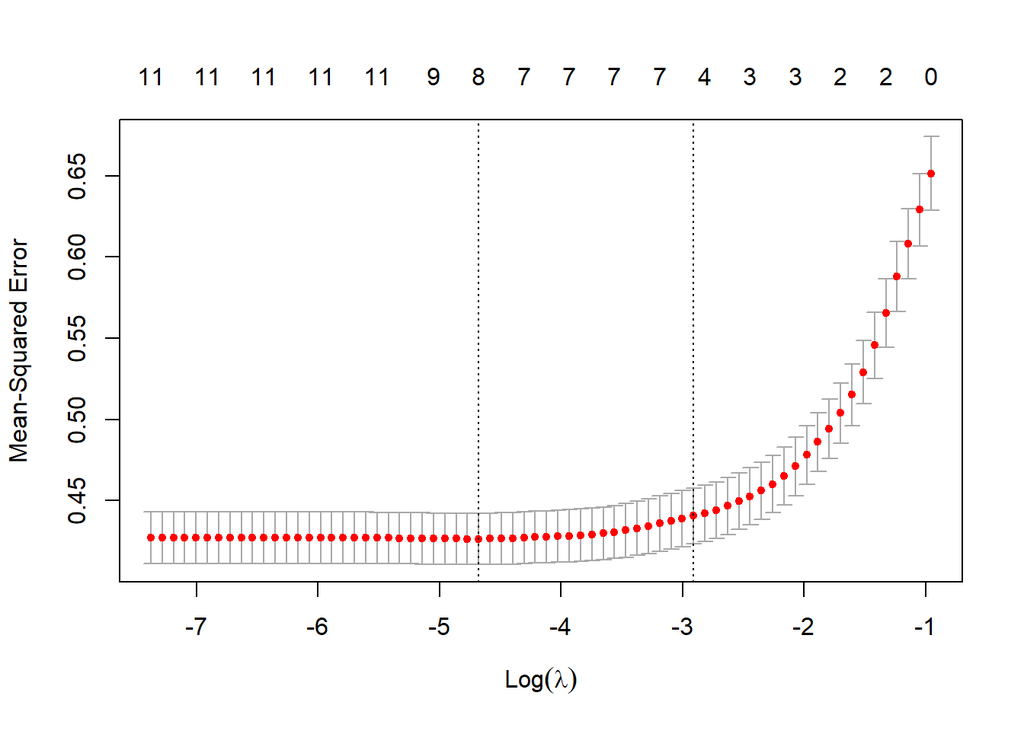

```r
set.seed(1)
results_lasso <- cv.glmnet(x=data.matrix(wine_x),
                           y=wine_y,
                           alpha=1,
                           nfolds=10)
plot(results_lasso)
```

The above plot shows the results obtained via cross validation for a range of values of $\lambda$.

The smallest average error obtained by cross validation occurred for the model with around eight non-zero coefficients, identified by the left-most vertical line. As we have seen previously, there is variability in the error obtained via the random allocation into folds at the heart of cross validation, meaning that other models provided statistically indistinguishably different errors. In this case, the model represented by the right-most vertical line with around four non-zero coefficients is the recommended model – it is the simplest model (largest $\lambda$, smallest number of non-zero coefficients) whose error is statistically indistinguishable from the model with the very smallest error.

```r
opt_fit_lasso <- glmnet(x=data.matrix(wine_x),
                        y=wine_y,
                        alpha = 1,
                        lambda = results_lasso$lambda.1se)
coef(opt_fit_lasso)
```

```
12 x 1 sparse Matrix of class "dgCMatrix"
                       s0
(Intercept)  3.1816030227
f_acidity    .
v_acidity   -1.0152494020
citric_acid  .
res_sugar    .
chlorides   -0.0885194274
free_so2     .
total_so2   -0.0008119963
density      .
pH           .
sulphates    0.4577701017
alcohol      0.2623512120
```

```r
library(cvTools)
```

```r
cv_opt_lasso <- cvFit(opt_fit_lasso,
                      data = data.matrix(wine_x),
                      y = wine_y,
                      k=5,
                      R=30 )
cv_opt_lasso$cv
```

```
       CV
0.6601587
```

```r
cv_opt_lasso$se
```

```
CV
 0
```

## Ridge regression

Similar to the lasso is a methodology referred to as ridge regression. Under this methodology, the selected model is the one which minimises:
$$\begin{align*}
RSS^* &= \sum_{i=1}^n \left(y_i - \lbrace \beta_0+\beta_1x_{1,i}+\beta_2x_{2,i}+...+\beta_px_{p,i}\rbrace \right)^2 + \lambda\sum_{j=1}^p\beta_j^2
\end{align*}$$

The influence of the tuning parameter, $\lambda$, is the same as in the case of the lasso.

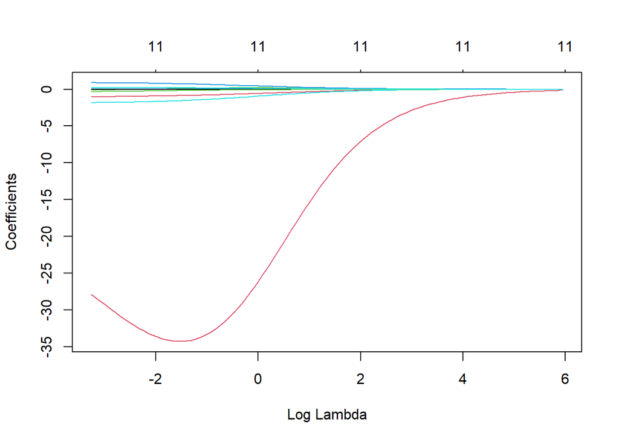

```r
fit_ridge <- glmnet(x=data.matrix(wine_x),
                    y=wine_y,
                    alpha = 0)
plot(fit_ridge, xvar="lambda")
```

See how, as (the logarithm of) $\lambda$ increases, coefficient values are “shrunk” towards zero. However, unlike the case in the lasso, they are not driven all of the way to zero.

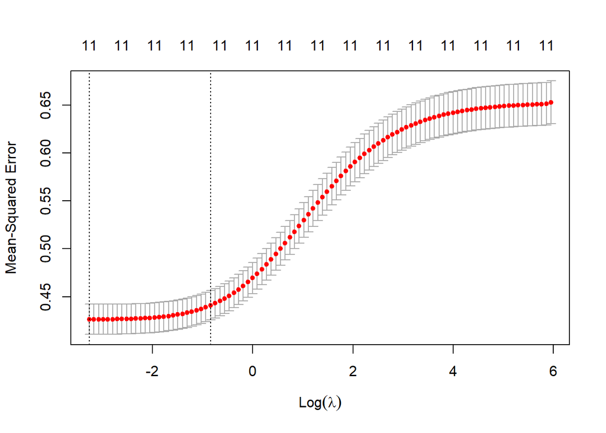

```r
set.seed(1)
results_ridge <- cv.glmnet(x=data.matrix(wine_x),
                           y=wine_y,
                           alpha=0,
                           nfolds=10)
plot(results_ridge)
```

The optimal model reported via ridge regression still contains $11$ non-zero coefficients. They are smaller than they would have been for full model without the shrinkage penalty, but the model doesn’t have the sparsity which we would prefer.

```r
opt_fit_ridge <- glmnet(x=data.matrix(wine_x),
                        y=wine_y,
                        alpha = 0,
                        lambda = results_ridge$lambda.1se)
coef(opt_fit_ridge)
```

```
12 x 1 sparse Matrix of class "dgCMatrix"
                       s0
(Intercept)  36.599813860
f_acidity     0.022635336
v_acidity    -0.745434627
citric_acid   0.180134683
res_sugar     0.013385197
chlorides    -1.309088673
free_so2      0.001041995
total_so2    -0.002111242
density     -32.620790439
pH           -0.120931259
sulphates     0.626046711
alcohol       0.178227896
```

```r
cv_opt_ridge <- cvFit(opt_fit_ridge,
                      data = data.matrix(wine_x),
                      y = wine_y,
                      k=5,
                      R=30 )
cv_opt_ridge$cv
```

```
       CV
0.6597769
```

```r
cv_opt_ridge$se
```

```
CV
 0
```

Despite the fact that ridge regression has not driven any of the coefficients to exactly zero, it still reports a lower cross validated error than the model obtained via the lasso, which did drive a majority of the coefficients to zero. In this case, we might still prefer the model resulting from the lasso – the difference in errors is very small, and the model obtained via the lasso is considerably more parsimonious (only five covariates, rather than eleven.)

While ridge regression doesn’t necessarily drive coefficient estimates to zero in the same way that the lasso does, it is computationally more efficient. This is a result of the form of $RSS^*$ for ridge regression – it is possible to optimise it analytically because it is differentiable in each of the $\beta_j$. $RSS^*$ is not differentiable as a function of the $\beta_j$ for the lasso, so numerical methods have to be used to optimise $RSS^*$.

## Covariate standardisation

It is a common pitfall of students new to statistics that the magnitude of coefficients in linear regression indicates the importance of their corresponding covariate.

For example, consider the model:
$$\begin{align*}
y = 0 + 1\times x_1 + 10\times x_2
\end{align*}$$
One might assume that $x_2$ is ten times as important as $x_1$ – changing $x_2$ by one unit has ten times the impact on $y$ as changing $x_1$ by one unit.

The missing piece from that argument is that the scales of $x_1$ and $x_2$ may vary. If $x_1$ varies between $0$ and $100$ and $x_2$ varies between $0$ and $0.01$, it is likely that $x_1$ will have a considerably greater impact on $y$ (through $1\times x_1$) than $x_2$ will have on $y$ (through $10\times x_2$).

Ridge regression and the lasso combine coefficient estimates in the penalty term without any scaling, reducing the size of coefficients for covariates determined to be less important. It is therefore imperative that the coefficients are on the same scale, ensured by standardising the covariates:
$$\begin{align*}
x' = \frac{x-mean(x)}{sd(x)}
\end{align*}$$

If we were to implement ridge regression or the lasso manually then we would need to carry out that standardisation. As it is, the implementation in R above standarises the covariates, performs the model fit, then reverses the standardisation process without requiring us to do anything ourselves.